# Project

### Customer Experience Analytics : An Exploratory Analysis of Amazon Fine Food Reviews

**Student Name :** Pandadiya Dharak Sanjaybhai

**Module :** M504 AI and Applications

**GH Number :** GH1057786

**Dataset :** Amazon Fine Food Reviews - Stanford Network Analysis Project (SNAP)

**Dataset Link :** https://www.kaggle.com/datasets/snap/amazon-fine-food-reviews

**Github Repository :** https://github.com/dharak07/AI-and-Application.git

### Academic Integrity Note

This notebook constitutes an individual exploratory data analysis project referred to as “Customer Experience Analytics : An Exploratory Analysis of Amazon Fine Food Reviews”, which uses data from the Amazon Fine Food Reviews dataset. All exploration, data preprocessing and analysis, visuals, interpretations, business insights, and conclusions in the final submission must represent the student’s understanding of the dataset and the analytical methods used. All external dataset, documentation, academic literature, code references, and any type of additional materials must be acknowledged and referenced according to the Harvard referencing style, and the source of the original dataset must be specified. The notebook must be reviewed before submission to ensure that the code is correct, runnable, and the written explanations represent the results accurately. According to the M504 assessment requirements, the design and implementation of the final project must be the student’s own work, and the usage of generative AI in the final project is not allowed.

### 1. Business Context

In the current study, I am administering analysis in the capacity of a data science consultant. The available data comprises the Amazon Fine Food Reviews dataset. The dataset essentially comprises different food products that received customer reviews. In it, product IDs, user IDs, score ratings, summary of reviews, their text and time stamps, along with information about their helpfulness are contained.

The motivation behind this study is to study the behavior of customers, which would help develop some valuable insights regarding customer behavior and different aspects of information that should be taken into consideration while interpreting the raw review information, as it may prove difficult to understand. Through this work, an EDA pipeline is developed based on Python and Pandas that would help transform raw review information into useful and meaningful insights.

### Main Objectives

1. This paper will focus on measuring customer ratings for food products.
2. The paper will also identify which food products received the best and worst ratings among the food products.
3. The paper will include how the usefulness of the feedback relates to the ratings given to the product.
4. It will also focus on understanding how customers behave in reviewing the products and the characteristics of the most active reviewers.
5. The project will also analyse how customer rating and review activity have changed over time.
6. Finally, the project will focus on the correlation between review length, usefulness, and product ratings.
7. By the end of the project, customers should get valuable insights from the analysis which can help improve the quality of good products.

### 2. Dataset Description

The Amazon Fine Food Review's dataset comprises the feedback and ratings of customers for food items sold on Amazon.com. It contains the product details, reviewer's information, rating scores, rating helpfulness, review date, as well as the review's brief and complete text.

| Column | Meaning |
| --- | --- |
| `Id` | Unique identifier for each review |
| `ProductId` | Unique identifier for the reviewed product |
| `UserId` | Unique identifier for the reviewer |
| `ProfileName` | Reviewer profile name |
| `HelpfulnessNumerator` | Number of users who found the review helpful |
| `HelpfulnessDenomintor` | Total number of users who rated the review's helpfulness |
| `Score` | Rating given to the product |
| `Time` | Timestamp showing when the review was posted |
| `Summary` | Short summary or title of the review |
| `Text` | Full written review |

This dataset is relevant to the research work because it provides an opportunity to evaluate customer ratings, product performance, reviews activity, helpfulness of reviews, trending analysis, and customer reviews with the use of programming languages Python and Pandas.

### 3. Module map : How the weekly topics become one project

| Weekly Topics | Application in This Project |
| --- | --- |
| `Introduction to Python` | Writing and running Python code Jupyter Notebook |
| `Expressions and Data Types` | Working with numerical, categorical, and text-based customer data |
| `Control Statements` | Using conditions to filter and compare users, products, reviews, and ratings |
| `Classes` | Learning concepts relevant to structured programming in Python |
| `Modules and Packages` | Importing libraries such as Pandas, NumPy, and Matplotlib |
| `NumPy` | Performing numerical calculations and statistical operations on review data |
| `Pandas` | Cleaning, transforming, grouping, and analysing the Amazon Fine Food Reviews dataset |
| `Data Analysis` | Solving business issues based on ratings, helpfulness, products, users and review activity |
| `Data Preprocessing` | Dealing with missing values, duplicate entries, timestamps, and creating analytical variables |
| `Conclusion` | Summarizing key outcomes, limitations, business recommendations, and general significance of the research |

### 4. Pipeline Logic

The project follows a structured EDA pipeline to transform the raw Amazon Fine Food Reviews into useful customer and product insights :

Data Collection -> Data Exploration -> Data Cleaning -> Data Preprocessing -> Exploratory Data Analysis -> Visualisation -> Business Interpretation -> Recommendations and Conclusion

The initial step in the process of data analysis is to analyze the dataset in order to understand the types of data and composition and determine if there are any missing or duplicated data and any other issues concerning quality. The second step is data preparation where one needs to deal with missing values, transform the `Time` variable into the Date and create new features like Review Length and Helpfulness Ratio among others.

### 5. Import Libraries

```python
import pandas as pd
import numpy as np
import matplotlib.pyplot as plt

pd.set_option('display.max_columns', None)
pd.set_option('display.float_format', lambda x: f"{x:,.2f}")
```

### 6. Load The Dataset

The Amazon Fine Food Review datset is brought into the notebook using the Pandas library. A copy of the data taken has been created to maintain the original form of the data. Following the importation of the CSV file, the resulting data file is shown so that the first lines can be checked to ensure that the data has been loaded correctly and to see the initial structure of the data, such as the column names, and sample records.

```python
# Load Bank Marketing dataset from local Data folder
dff = "../Data/reviews.csv"

# Create a copy to preserve the original dataset
try:
    df = pd.read_csv(dff)
    print("Dataset loaded successfully.")
except FileNotFoundError:
    print("File not found:", dff)
    print('Upload Bank.csv file to the Data folder to proceed.')
```

```
Dataset loaded successfully.
```

### 7. Initial Data Exploration

```python
# Display the first few rows of the dataset

display(df.head())
```

|  | Id | ProductId | UserId | ProfileName | HelpfulnessNumerator | HelpfulnessDenominator | Score | Time | Summary | Text |
| --- | --- | --- | --- | --- | --- | --- | --- | --- | --- | --- |
| 0 | 1 | B001E4KFG0 | A3SGXH7AUHU8GW | delmartian | 1 | 1 | 5 | 1303862400 | Good Quality Dog Food | I have bought several of the Vitality canned d... |
| 1 | 2 | B00813GRG4 | A1D87F6ZCVE5NK | dll pa | 0 | 0 | 1 | 1346976000 | Not as Advertised | Product arrived labeled as Jumbo Salted Peanut... |
| 2 | 3 | B000LQOCH0 | ABXLMWJIXXAIN | Natalia Corres "Natalia Corres" | 1 | 1 | 4 | 1219017600 | "Delight" says it all | This is a confection that has been around a fe... |
| 3 | 4 | B000UA0QIQ | A395BORC6FGVXV | Karl | 3 | 3 | 2 | 1307923200 | Cough Medicine | If you are looking for the secret ingredient i... |
| 4 | 5 | B006K2ZZ7K | A1UQRSCLF8GW1T | Michael D. Bigham "M. Wassir" | 0 | 0 | 5 | 1350777600 | Great taffy | Great taffy at a great price. There was a wid... |

**Observation** : In my observation the first few records from Amazon Fine Food Reviews data, it can be concluded that the data has been successfully extracted and all data types - numerical, categorical, timestamp, and textual - have been loaded correctly. It can be seen from the samples provided in the dataset that there are product identifiers, the list of users that wrote reviews, the score of review, information about helpfulness, a short review, and a full review.

```python
# Display the shape and information of the dataset

print("Rows and columns:", df.shape)
print("\nColumns information:")
df.info()
```

```
Rows and columns: (47576, 10)

Columns information:
<class 'pandas.core.frame.DataFrame'>
RangeIndex: 47576 entries, 0 to 47575
Data columns (total 10 columns):
 #   Column                  Non-Null Count  Dtype
---  ------                  --------------  -----
 0   Id                      47576 non-null  int64
 1   ProductId               47576 non-null  object
 2   UserId                  47576 non-null  object
 3   ProfileName             47573 non-null  object
 4   HelpfulnessNumerator    47576 non-null  int64
 5   HelpfulnessDenominator  47576 non-null  int64
 6   Score                   47576 non-null  int64
 7   Time                    47576 non-null  int64
 8   Summary                 47574 non-null  object
 9   Text                    47576 non-null  object
dtypes: int64(5), object(5)
memory usage: 3.6+ MB
```

```python
# Display the summary statistics of the dataset

display(df.describe(include='all'))
```

|  | Id | ProductId | UserId | ProfileName | HelpfulnessNumerator | HelpfulnessDenominator | Score | Time | Summary | Text |
| --- | --- | --- | --- | --- | --- | --- | --- | --- | --- | --- |
| count | 47,576.00 | 47576 | 47576 | 47573 | 47,576.00 | 47,576.00 | 47,576.00 | 47,576.00 | 47574 | 47576 |
| unique | NaN | 5897 | 38162 | 35296 | NaN | NaN | NaN | NaN | 37253 | 44027 |
| top | NaN | B002QWP89S | AY12DBB0U420B | Gary Peterson | NaN | NaN | NaN | NaN | Delicious! | Diamond Almonds<br />Almonds are a good source... |
| freq | NaN | 632 | 42 | 42 | NaN | NaN | NaN | NaN | 185 | 21 |
| mean | 23,788.50 | NaN | NaN | NaN | 1.61 | 2.06 | 4.15 | 1,294,913,958.03 | NaN | NaN |
| std | 13,734.15 | NaN | NaN | NaN | 5.65 | 6.24 | 1.32 | 47,300,326.07 | NaN | NaN |
| min | 1.00 | NaN | NaN | NaN | 0.00 | 0.00 | 1.00 | 961,718,400.00 | NaN | NaN |
| 25% | 11,894.75 | NaN | NaN | NaN | 0.00 | 0.00 | 4.00 | 1,269,129,600.00 | NaN | NaN |
| 50% | 23,788.50 | NaN | NaN | NaN | 0.00 | 1.00 | 5.00 | 1,308,700,800.00 | NaN | NaN |
| 75% | 35,682.25 | NaN | NaN | NaN | 2.00 | 2.00 | 5.00 | 1,330,819,200.00 | NaN | NaN |
| max | 47,576.00 | NaN | NaN | NaN | 398.00 | 401.00 | 5.00 | 1,351,209,600.00 | NaN | NaN |

**Observation** : The summary statistics show a comprehensive summary of the data by revealing the distribution of numerical variables as well as most common values for categorical variables. This allows to identify trends regarding review scores, helpfulness, review date, as well as product and consumer usage patterns, thus showing potential outliers or deviations.

```python
# Missing Values Analysis
missing_values = df.isnull().sum().sort_values(ascending=False)
display(missing_values)

# Duplicate Rows Analysis
print("Number of duplicate rows:", df.duplicated().sum())
```

```
ProfileName               3
Summary                   2
ProductId                 0
Id                        0
HelpfulnessNumerator      0
UserId                    0
HelpfulnessDenominator    0
Score                     0
Time                      0
Text                      0
dtype: int64
```

```
Number of duplicate rows: 0
```

**Observation** : The missing-value analysis that was carried out indicates that the dataset is mostly complete with a small percentage of missing values detected mostly in `ProfileName` and `Summary` columns. The duplicate check is used to get rid of duplicate entries related to the same review record to prepare the dataset for further data analysis.

```python
clean_df = df.dropna().copy()

print("Original shape:", df.shape)
print("Cleaned shape:", clean_df.shape)
```

```
Original shape: (47576, 10)
Cleaned shape: (47571, 10)
```

**Observation** : In this phase of the process, reviews with undesirable information are removed. The dataset becomes more usable and more suitable for further investigation, because there are missing fields such as `ProfileName` and `Summary`. However, since the number of missing records is small, the deletion of those records doesn’t affect the size of the dataset much.

```python
null_summary = pd.DataFrame({
    'null_count': df.isnull().sum(),
    'null_percentage': (df.isnull().sum() / len(df)) * 100
})

# print("\nNull Values Summary:", null_summary)

display(null_summary)
```

|  | null_count | null_percentage |
| --- | --- | --- |
| Id | 0 | 0.00 |
| ProductId | 0 | 0.00 |
| UserId | 0 | 0.00 |
| ProfileName | 3 | 0.01 |
| HelpfulnessNumerator | 0 | 0.00 |
| HelpfulnessDenominator | 0 | 0.00 |
| Score | 0 | 0.00 |
| Time | 0 | 0.00 |
| Summary | 2 | 0.00 |
| Text | 0 | 0.00 |

**Observation** : The null-value summary indicates the total number and percentage of blank values found in every field which proves beneficial to pinpoint the variables that are in need of cleaning. In this dataset, missing values are expected primarily in numerous text fields i.e. `ProfileName` and `Summary` while other fields are virtually complete.

### Examination of Data

The Amazon Fine Food Reviews database has a large collection of user-written reviews with both number and text information. Each record has several fields, including the product and user codes, review scores, and times when the review was written, as well as the short summaries and full text of the review. A preliminary inspection of the database shows that it is rich enough for analysis of customer satisfaction, reviewer activity and efficiency, product performance, and review usefulness.

The database has an appropriate structure and layout. However, a few issues related to data quality should be solved before the analysis takes place. Finally, it should be noticed that the variable called `Time` is stored in the database in the form of a number and should be converted into a human-readable format.

### 8. Data Preprocessing

The aim of the data preprocessing technique is to enhance the quality and uniformity of the Amazon Fine Food Reviews dataset before the exploratory analysis. Though many fields are filled, there are still some missing values in columns like ProfileName and Summary, while it is possible to have duplicate records.

1. Eliminate any repetitive records of reviews.
2. Deal with the unavailability of data in columns `ProfileName` and `Summary`.
3. Transform the column `Time` from the Unix timestamp format into a user-readable format.
4. Create features related to `Year` and `Month`.
5. Design a new feature `ReviewLength` which will be extracted from the `Text` column.
6. Compute a `HelpfulnessRatio` from the `HelpfulnessNumerator` and `HelpfulnessDenominator` values.
7. Ensure that the values of review `Score` are within the permissible range of values.

```python
# Create a copy to preserve the raw dataset
clean_df = df.copy()

# Standardize column names
clean_df.columns = clean_df.columns.str.strip()

# Remove duplicate rows
clean_df = clean_df.drop_duplicates()

# Handle missing values in important text columns
clean_df['ProfileName'] = clean_df['ProfileName'].fillna('Unknown')
clean_df['Summary'] = clean_df['Summary'].fillna('No Summary')
clean_df['Text'] = clean_df['Text'].fillna('')

# Convert Unix timestamp into readable datetime
clean_df['ReviewDate'] = pd.to_datetime(
    clean_df['Time'],
    unit='s'
)

# Create time-based features
clean_df['Year'] = clean_df['ReviewDate'].dt.year
clean_df['Month'] = clean_df['ReviewDate'].dt.month
clean_df['MonthName'] = clean_df['ReviewDate'].dt.month_name()

# Create review length feature
clean_df['ReviewLength'] = clean_df['Text'].str.split().str.len()

# Create helpfulness ratio
clean_df['HelpfulnessRatio'] = np.where(
    clean_df['HelpfulnessDenominator'] > 0,
    clean_df['HelpfulnessNumerator'] /
    clean_df['HelpfulnessDenominator'],
    0
)

# Check valid rating scores
clean_df = clean_df[
    clean_df['Score'].between(1, 5)
].copy()

print("Cleaned dataset shape:", clean_df.shape)
display(clean_df.head())
```

```
Cleaned dataset shape: (47576, 16)
```

|  | Id | ProductId | UserId | ProfileName | HelpfulnessNumerator | HelpfulnessDenominator | Score | Time | Summary | Text | ReviewDate | Year | Month | MonthName | ReviewLength | HelpfulnessRatio |
| --- | --- | --- | --- | --- | --- | --- | --- | --- | --- | --- | --- | --- | --- | --- | --- | --- |
| 0 | 1 | B001E4KFG0 | A3SGXH7AUHU8GW | delmartian | 1 | 1 | 5 | 1303862400 | Good Quality Dog Food | I have bought several of the Vitality canned d... | 2011-04-27 | 2011 | 4 | April | 48 | 1.00 |
| 1 | 2 | B00813GRG4 | A1D87F6ZCVE5NK | dll pa | 0 | 0 | 1 | 1346976000 | Not as Advertised | Product arrived labeled as Jumbo Salted Peanut... | 2012-09-07 | 2012 | 9 | September | 31 | 0.00 |
| 2 | 3 | B000LQOCH0 | ABXLMWJIXXAIN | Natalia Corres "Natalia Corres" | 1 | 1 | 4 | 1219017600 | "Delight" says it all | This is a confection that has been around a fe... | 2008-08-18 | 2008 | 8 | August | 94 | 1.00 |
| 3 | 4 | B000UA0QIQ | A395BORC6FGVXV | Karl | 3 | 3 | 2 | 1307923200 | Cough Medicine | If you are looking for the secret ingredient i... | 2011-06-13 | 2011 | 6 | June | 41 | 1.00 |
| 4 | 5 | B006K2ZZ7K | A1UQRSCLF8GW1T | Michael D. Bigham "M. Wassir" | 0 | 0 | 5 | 1350777600 | Great taffy | Great taffy at a great price. There was a wid... | 2012-10-21 | 2012 | 10 | October | 27 | 0.00 |

**Observation** : The process of preprocessing borrows its definitions from the task of elimination of repeated records, filling in the blanks of missing text values, converting timestamps into readable date format, as well as extraction of useful features such as `Year`, `Month`, `ReviewLength`, and `HelpfulnessRatio`.

```python
# Verify Cleaning
print("Missing values after cleaning:")
display(clean_df.isnull().sum())

# Check duplicate rows
print("Duplicate rows after Cleaning:", clean_df.duplicated().sum())

# Check rating range
print("Minimum review score:", clean_df['Score'].min())
print("Maximum review score:", clean_df['Score'].max())

# Check review length
print("Minimum review length:", clean_df['ReviewLength'].min())
print("Maximum review length:", clean_df['ReviewLength'].max())

# Check helpfulness ratio
print("Minimum helpfulness ratio:", clean_df['HelpfulnessRatio'].min())
print("Maximum helpfulness ratio:", clean_df['HelpfulnessRatio'].max())

# Check review date range
print("Earliest review date:", clean_df['ReviewDate'].min())
print("Latest review date:", clean_df['ReviewDate'].max())

# Check rating distribution
print("\nReview Score Distribution:")
display(
    clean_df['Score']
    .value_counts()
    .sort_index()
)
```

```
Missing values after cleaning:
```

```
Id                        0
ProductId                 0
UserId                    0
ProfileName               0
HelpfulnessNumerator      0
HelpfulnessDenominator    0
Score                     0
Time                      0
Summary                   0
Text                      0
ReviewDate                0
Year                      0
Month                     0
MonthName                 0
ReviewLength              0
HelpfulnessRatio          0
dtype: int64
```

```
Duplicate rows after Cleaning: 0
Minimum review score: 1
Maximum review score: 5
Minimum review length: 6
Maximum review length: 1751
Minimum helpfulness ratio: 0.0
Maximum helpfulness ratio: 1.5
Earliest review date: 2000-06-23 00:00:00
Latest review date: 2012-10-26 00:00:00

Review Score Distribution:
```

```
Score
1     4438
2     2682
3     3859
4     6899
5    29698
Name: count, dtype: int64
```

### Preprocessing Discussion

The preprocessing phase was also essential in introducing several analytical variables that help the researchers analyze the dataset in a more informative way. `ReviewLength` is one of these variables. It contains the values derived from the length of the review, namely the number of words.

### 9. Explanatory Data Analysis

**Business Question 1** : How are customer rating scores distributed across Amazon Fine Food products?

**Importance** : When analyzing the total customer satisfaction, it is very important to analyze the ratings.

|  | Score | Number_of_Reviews | percentage |
| --- | --- | --- | --- |
| 0 | 1 | 4438 | 9.33 |
| 1 | 2 | 2682 | 5.64 |
| 2 | 3 | 3859 | 8.11 |
| 3 | 4 | 6899 | 14.50 |
| 4 | 5 | 29698 | 62.42 |

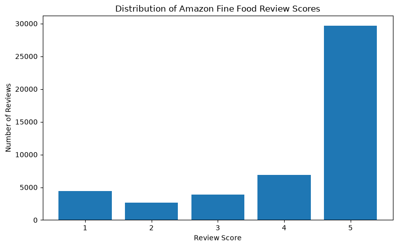

```python
# Calculate number of reviews for each rating score
score_distribution = (
    clean_df['Score']
    .value_counts()
    .sort_index()
    .reset_index()
)

score_distribution.columns = ['Score','Number_of_Reviews']

# Calculate percentage of total reviews
score_distribution['percentage'] = (
    score_distribution['Number_of_Reviews']
    / score_distribution['Number_of_Reviews'].sum()
) * 100

display(score_distribution)

# Visualisation - Bar Chart
import matplotlib.pyplot as plt

plt.figure(figsize=(8, 5))

plt.bar(
    score_distribution['Score'],
    score_distribution['Number_of_Reviews']
)

plt.title('Distribution of Amazon Fine Food Review Scores')
plt.xlabel('Review Score')
plt.ylabel('Number of Reviews')
plt.xticks([1, 2, 3, 4, 5])
plt.tight_layout()

plt.show()
```

**Observation** : In this analysis, the number and proportion of reviews based on all five rating scales will be compared. Hence, it would be possible to determine which ratings have been most often given, as well as whether customer reviews are mostly positive, negative, or neutral.

**Buisness Question 2** : Which products achieve the strongest ratings while also receiving a substantial number of reviews?

**Importance** : While an item might receive a perfect score of 5 based on a small number of reviews, it can’t be considered as trustworthy as another product with a 5-star rating garnered from hundreds of reviews. This leads to the point that the analysis combines `average score and review quantity` in order to find out which items, besides demonstrating high rating average, also have a decent amount of positive feedback.

|  | ProductId | Review_Count | Average_Score |
| --- | --- | --- | --- |
| 3585 | B0032RPLSY | 60 | 4.77 |
| 2460 | B001EQ5JLE | 212 | 4.75 |
| 260 | B000255OIG | 173 | 4.75 |
| 27 | B00008JOL0 | 98 | 4.74 |
| 748 | B000EVIDUY | 91 | 4.74 |
| 3133 | B0029NTQ1K | 137 | 4.72 |
| 3140 | B0029O10P4 | 137 | 4.72 |
| 5156 | B005GIF5VU | 137 | 4.72 |
| 5770 | B0083QJU72 | 165 | 4.70 |
| 2426 | B001EQ4P2I | 174 | 4.68 |
| 2246 | B001E5DXEU | 123 | 4.67 |
| 4373 | B0047E2I5U | 69 | 4.67 |
| 1877 | B0013E21V8 | 71 | 4.63 |
| 3985 | B003TIVBSU | 69 | 4.62 |
| 5251 | B005MGDP86 | 73 | 4.62 |

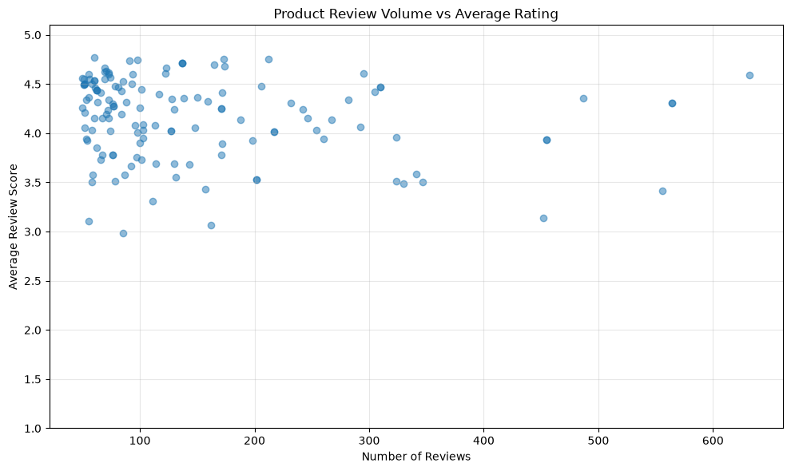

```python
# Analyse product performance using review volume and average score
product_performance = (
    clean_df.groupby('ProductId')
    .agg(
        Review_Count=('Id','count'),
        Average_Score=('Score','mean')
    )
    .reset_index()
)

# Keep products with at least 50 reviews
reliable_products = product_performance[
    product_performance['Review_Count'] >= 50
].copy()

# Identify the top 15 products
top_products = (
    reliable_products
    .sort_values(
        by=['Average_Score', 'Review_Count'],
        ascending=[False, False]
    )
    .head(15)
)

display(top_products)

# Visualisation - Scatter Plot
import matplotlib.pyplot as plt

plt.figure(figsize=(10, 6))

plt.scatter(
    reliable_products['Review_Count'],
    reliable_products['Average_Score'],
    alpha=0.5
)

plt.title('Product Review Volume vs Average Rating')
plt.xlabel('Number of Reviews')
plt.ylabel('Average Review Score')
plt.ylim(1, 5.1)
plt.grid(alpha=0.3)
plt.tight_layout()

plt.show()
```

**Observation** : The scatter plot illustrates the different products that pass two important criteria which are the total number of reviews received and the average rating given by consumers. The position of a product on the plot indicates how high the average rating is, while its location on the horizontal axis reflects how many reviews it has received. In this way, the method eliminates the risk of poor products being classified as bestsellers on the basis of a few excellent reviews only, as it only counts products that received at least 50 reviews.

**Business Question 3** : Does review length influence how helpful customers find a review?

**Importance** : Length of a customer review might influence the level of detail a customer may provide about his experience with the product. In relation to the helpfulness score received, it might prove useful to assess if long reviews or short ones are more beneficial. Companies may also gain from information concerning the usefulness of long reviews in assisting consumers in making their purchase decisions.

|  | ReviewLengthGroup | Number_of_Reviews | Average_Helpfulness |
| --- | --- | --- | --- |
| 0 | very Short | 6139 | 31.24 |
| 1 | Short | 14865 | 35.31 |
| 2 | Medium | 15154 | 41.62 |
| 3 | Long | 8620 | 48.12 |
| 4 | Very Long | 2798 | 53.20 |

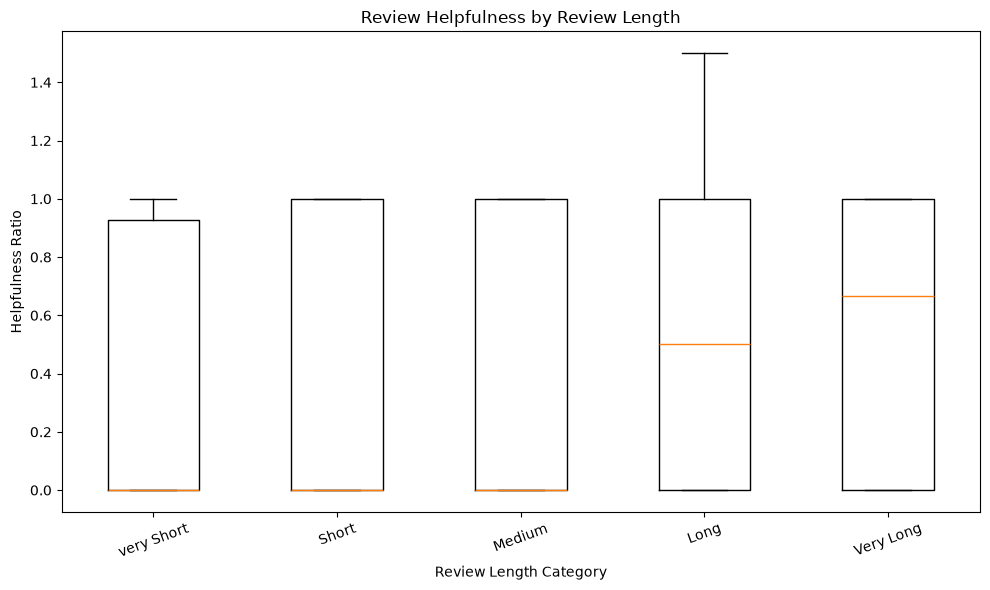

```python
# Create review length categories
clean_df['ReviewLengthGroup'] = pd.cut(
    clean_df['ReviewLength'],
    bins=[0, 25, 50, 100, 200, float('inf')],
    labels=[
        'very Short',
        'Short',
        'Medium',
        'Long',
        'Very Long'
    ]
)

# Calculate helpfulness statistics for each review length group
length_helpfulness = (
    clean_df.groupby('ReviewLengthGroup', observed=False)
    .agg(
        Number_of_Reviews=('Id', 'count'),
        Average_Helpfulness=('HelpfulnessRatio', 'mean')
    )
    .reset_index()
)

length_helpfulness['Average_Helpfulness'] *= 100

display(length_helpfulness)

# Visualisation - Bar Plot

plot_data = [
    clean_df.loc[
        clean_df['ReviewLengthGroup'] == group,
        'HelpfulnessRatio'
    ].dropna()
    for group in clean_df['ReviewLengthGroup'].cat.categories
]

plt.figure(figsize=(10, 6))

plt.boxplot(
    plot_data,
    tick_labels = clean_df['ReviewLengthGroup'].cat.categories,
    showfliers=False
)

plt.title('Review Helpfulness by Review Length')
plt.xlabel('Review Length Category')
plt.ylabel('Helpfulness Ratio')
plt.xticks(rotation=20)
plt.tight_layout()

plt.show()
```

**Observation** : The boxplot illustrates the variance of helpfulness ratios for different review lengths from shorter ones to longer ones. This would tell us whether longer reviews would mean more helpful information received by customers or not. If longer reviews have higher median helpfulness ratios, that would likely mean that consumers find helpful experience with a product helpful in their purchase decisions.

**Business Question 4** : Are extremely positive or negative reviews considered more helpful than moderate reviews?

**Importance** : Before making a purchase, customers often look to reviews for information about a product’s advantages and disadvantages. Ratings allow us to discover what customers think about the value of positive, negative, or neutral reviews in terms of usefulness. This will aid companies in realizing which type of customer feedback works best in helping other customers.

|  | Score | Number_of_Reviews | Average_Helpfulness | Median_Helpfulness |
| --- | --- | --- | --- | --- |
| 0 | 1 | 3405 | 54.29 | 50.00 |
| 1 | 2 | 1709 | 57.24 | 66.67 |
| 2 | 3 | 2126 | 64.24 | 75.74 |
| 3 | 4 | 3312 | 79.98 | 100.00 |
| 4 | 5 | 14084 | 87.13 | 100.00 |

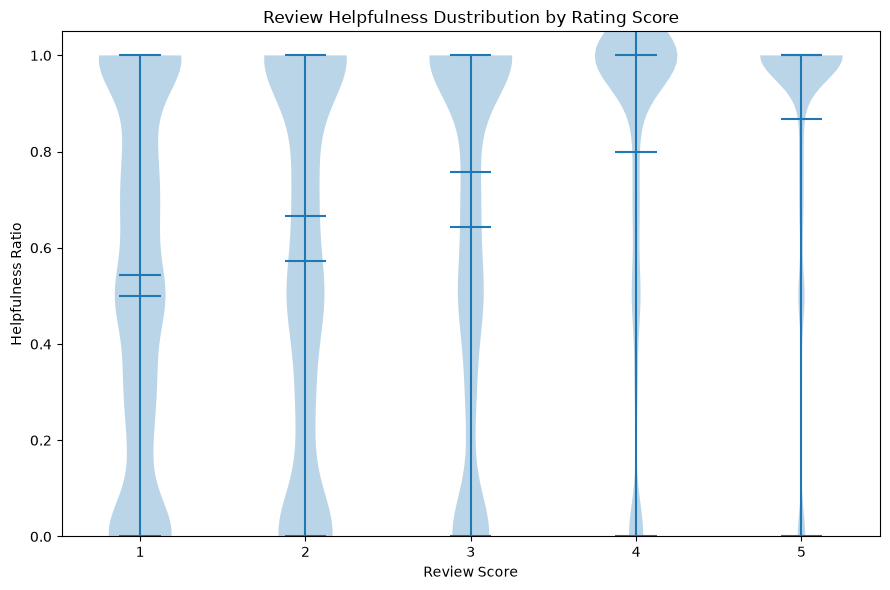

```python
# Use only reviews that received at least one helpfulness vote
helpfulness_data = clean_df[
    clean_df['HelpfulnessDenominator'] > 0
].copy()

# Calculate helpfulness statistics for each review score
score_helpfulness = (
    helpfulness_data.groupby('Score')
    .agg(
        Number_of_Reviews = ('Id', 'count'),
        Average_Helpfulness = ('HelpfulnessRatio', 'mean'),
        Median_Helpfulness = ('HelpfulnessRatio', 'median')
    )
    .reset_index()
)

# Convert helpfulness values into percentage
score_helpfulness['Average_Helpfulness'] *= 100
score_helpfulness['Median_Helpfulness'] *= 100

display(score_helpfulness)

# Create data for violin plot
plot_data = [
    helpfulness_data.loc[
        helpfulness_data['Score'] == score,
        'HelpfulnessRatio'
    ].sample(
        n=min(
            5000,
            len(helpfulness_data[
                helpfulness_data['Score'] == score
            ])
        ),
        random_state = 42
    )
    for score in range(1, 6)
]

# Visualisation - Violin Plot
plt.figure(figsize=(9, 6))

plt.violinplot(
    plot_data,
    positions=[1, 2, 3, 4, 5],
    showmeans=True,
    showmedians=True
)

plt.title('Review Helpfulness Dustribution by Rating Score')
plt.xlabel('Review Score')
plt.ylabel('Helpfulness Ratio')
plt.xticks([1, 2, 3, 4, 5])
plt.ylim(0, 1.05)
plt.tight_layout()

plt.show()
```

**Observation** : This analysis evaluates the information contained in reviews at each one of the five rating levels. It does not include reviews with no values in the helpfulness column since being shown a zero means that no one made a determination on the helpfulness of the review. The data visual is designed to both show distribution and concentration of helpfulness rates among ratings.

**Business Question 5** : Which reviewers have the greatest influence based on review activity and helpfulness?

**Importance** : Some consumers send quite a large number of reviews while others submit fewer reviews that other consumers find very beneficial to them. Identifying users who show both great activity as well as great usefulness can point to significant players in the consumers’ review community. Such users could provide particularly useful feedback on products making it easier for a company to figure out extensive information about the opinions of consumers and their buying experience.

|  | UserId | Review_Count | Average_Helpfulness | Influence_Score |
| --- | --- | --- | --- | --- |
| 9199 | A1WX42M589VAMQ | 12 | 0.88 | 10.50 |
| 12286 | A281NPSIMI1C2R | 25 | 0.43 | 10.71 |
| 27339 | A3PJZ8TU8FDQ1K | 21 | 0.54 | 11.30 |
| 37624 | AY12DBB0U420B | 42 | 0.30 | 12.45 |
| 18324 | A2SZLNSI5KOQJT | 22 | 0.58 | 12.74 |
| 35579 | AQQLWCMRNDFGI | 16 | 0.86 | 13.71 |
| 27146 | A3OXHLG6DIBRW8 | 37 | 0.39 | 14.53 |
| 9820 | A1Z54EM24Y40LL | 34 | 0.44 | 15.00 |
| 25110 | A3HPCRD9RX351S | 21 | 0.90 | 18.93 |
| 9742 | A1YUL9PCJR3JTY | 32 | 0.84 | 26.83 |

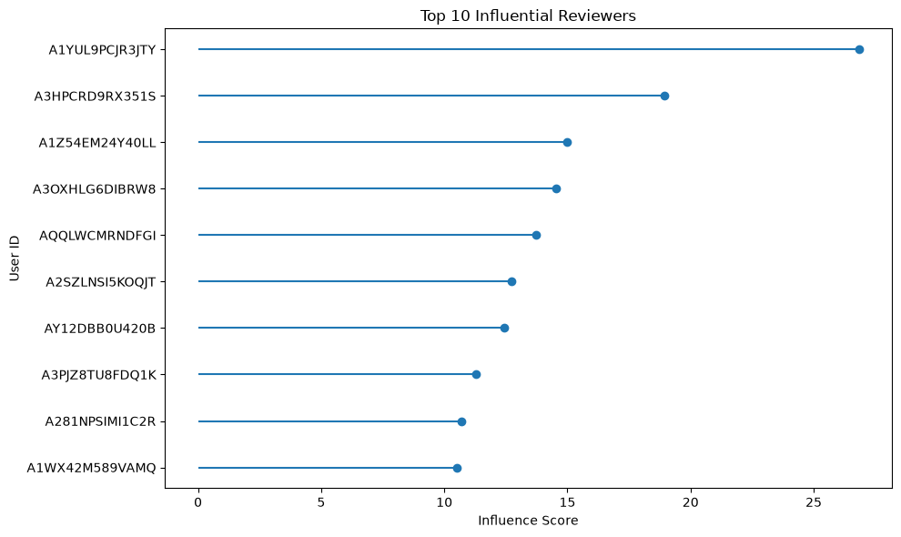

```python
# Calculate reviewer-level statistics
reviewer_analysis = (
    clean_df.groupby('UserId')
    .agg(
        Review_Count=('Id', 'count'),
        Average_Helpfulness=('HelpfulnessRatio', 'mean')
    )
    .reset_index()
)

# Keep reviewers with at least 10 reviews
active_reviewers = reviewer_analysis[
    reviewer_analysis['Review_Count'] >= 10
].copy()

# Create an influence score
active_reviewers['Influence_Score'] = (
    active_reviewers['Review_Count'] *
    active_reviewers['Average_Helpfulness']
)

# Select top 10 influential reviewers
top_reviewers = (
    active_reviewers
    .sort_values('Influence_Score', ascending=False)
    .head(10)
    .sort_values('Influence_Score')
)

display(top_reviewers)

# Visualisation - Lollipop Chart
import matplotlib.pyplot as plt

plt.figure(figsize=(10, 6))

plt.hlines(
    y=top_reviewers['UserId'],
    xmin=0,
    xmax=top_reviewers['Influence_Score']
)

plt.plot(
    top_reviewers['Influence_Score'],
    top_reviewers['UserId'],
    'o'
)

plt.title('Top 10 Influential Reviewers')
plt.xlabel('Influence Score')
plt.ylabel('User ID')
plt.tight_layout()

plt.show()
```

**Observation** : The analysis highlights the reviewers that combine high activity in terms of reviewing with high helpfulness levels. Instead of simply ranking reviewers by the number of reviews submitted, the influence score combines the frequency of contribution as well as the perceived usefulness of those reviews for other consumers. Reviewers who are positioned on the right side of the lollipop chart are the ones with the most influence.

**Business Question 6** : How have review activity and average customer ratings changed over time?

**Importance** : Analyzing the action of reviews leads to the understanding of the way customer behavior in relation to Amazon Fine Food goods has changed. The average rate will provide the information about whether customers’ satisfaction is on stable level or has become higher or lower as compared to previous periods.

|  | Year | Review_Count | Average_Score |
| --- | --- | --- | --- |
| 0 | 2000 | 2 | 5.00 |
| 1 | 2001 | 0 | NaN |
| 2 | 2002 | 0 | NaN |
| 3 | 2003 | 9 | 4.78 |
| 4 | 2004 | 51 | 4.27 |
| 5 | 2005 | 130 | 4.49 |
| 6 | 2006 | 496 | 4.46 |
| 7 | 2007 | 1740 | 4.40 |
| 8 | 2008 | 2962 | 4.33 |
| 9 | 2009 | 5141 | 4.17 |
| 10 | 2010 | 7336 | 4.18 |
| 11 | 2011 | 14037 | 4.12 |
| 12 | 2012 | 15672 | 4.08 |

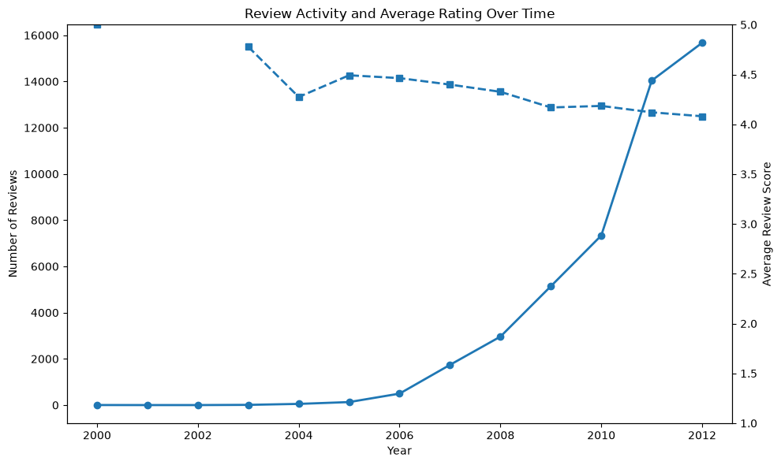

```python
time_analysis = (
    clean_df
    .set_index('ReviewDate')
    .resample('YE')
    .agg(
        Review_Count=('Id','count'),
        Average_Score=('Score','mean')
    )
    .reset_index()
)

# Extract year for display
time_analysis['Year'] = time_analysis['ReviewDate'].dt.year

display(
    time_analysis[
        ['Year','Review_Count','Average_Score']
    ]
)

# Visualisation - Dual Axis Line Chart
fig, ax1 = plt.subplots(figsize=(10, 6))

# Review volume
ax1.plot(
    time_analysis['Year'],
    time_analysis['Review_Count'],
    marker='o',
    linewidth=2
)

ax1.set_xlabel('Year')
ax1.set_ylabel('Number of Reviews')

# Second axis for average rating
ax2 = ax1.twinx()

ax2.plot(
    time_analysis['Year'],
    time_analysis['Average_Score'],
    marker='s',
    linestyle='--',
    linewidth=2
)

ax2.set_ylabel('Average Review Score')
ax2.set_ylim(1, 5)

plt.title('Review Activity and Average Rating Over Time')

fig.tight_layout()
plt.show()
```

**Observation** : The study monitors two key metrics over time: the number of reviews written by customers each year and the average ratings assigned by them. The first graph presents information of how many reviews were received for each year of interest, while the second provides evidence whether the average rating has changed over the same period of time.

**Business Question 7** : Which products generate the most disagreement among customers?

**Importance** : According to the high average rating, it cannot be concluded that the customers approve of the product. It is seen that some products gain very high ratings as well as very low ratings meaning different people have different experiences or expectations. The analysis of the variability of the ratings helps to find products that may need special attention since mixed opinions always signify inconsistency in quality, tastes, packaging issues, or other matters regarding the product.

|  | ProductId | Review_Count | Average_Score | Rating_Std |
| --- | --- | --- | --- | --- |
| 2134 | B001AJ1ULS | 202 | 3.53 | 1.83 |
| 1899 | B00141UC9I | 202 | 3.53 | 1.83 |
| 792 | B000F6SNPS | 143 | 3.69 | 1.76 |
| 22 | B000084ETV | 130 | 3.69 | 1.73 |
| 3556 | B0030VBRIU | 157 | 3.43 | 1.69 |
| 2600 | B001HTJ2BQ | 111 | 3.31 | 1.67 |
| 889 | B000FNEX50 | 59 | 3.58 | 1.66 |
| 1750 | B000YSS7EO | 171 | 3.78 | 1.65 |
| 3219 | B002DLXXHG | 162 | 3.06 | 1.65 |
| 2104 | B0019QG5CG | 58 | 3.50 | 1.65 |
| 4498 | B004CLCEDE | 324 | 3.51 | 1.63 |
| 2287 | B001ELL86Y | 66 | 3.73 | 1.59 |
| 1898 | B00141QYSQ | 74 | 4.03 | 1.59 |
| 3594 | B0033HGLTG | 54 | 3.93 | 1.56 |
| 3078 | B00284TR82 | 62 | 3.85 | 1.56 |

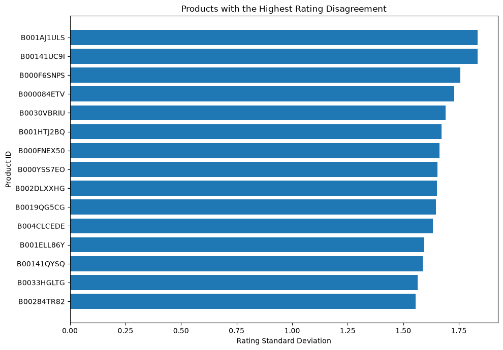

```python
# Calculate rating variability for each product
product_variability = (
    clean_df.groupby('ProductId')
    .agg(
        Review_Count=('Id','count'),
        Average_Score=('Score','mean'),
        Rating_Std=('Score','std')
    )
    .reset_index()
)

# Keep products with enough reviews for reliable comparison
product_variability = product_variability[
    product_variability['Review_Count'] >= 50
].copy()

# Select the 15 products with the highest rating variation
most_divisive_products = (
    product_variability
    .sort_values('Rating_Std',ascending=False)
    .head(15)
)

display(most_divisive_products)

plt.figure(figsize=(10, 7))

plt.barh(
    most_divisive_products['ProductId'],
    most_divisive_products['Rating_Std']
)

plt.title('Products with the Highest Rating Disagreement')
plt.xlabel('Rating Standard Deviation')
plt.ylabel('Product ID')

plt.gca().invert_yaxis()
plt.tight_layout()

plt.show()
```

**Observation** : The analysis points out those products, which experience the largest differences in customers’ ratings. A higher standard deviation means larger divergence in views regarding a product that receives both positive and negative ratings. The research focuses on products being rated by at least 50 users to ensure comparability of results and to lessen the effect of products being rated by too few customers.

**Business Question 8** : What combination of rating score and review length products the most helpful customer feedback?

**Importance** : This question considers multiple characteristics of reviews together, instead of looking at them separately. It is probable that if a review is useful, it does not always matter whether the rating is good or bad. The combination of score and review length is essential in understanding which reviews people find most useful.

| ReviewLengthGroup Score | Very Short | Short | Medium | Long | Very Long |
| --- | --- | --- | --- | --- | --- |
| 1 | 41.04 | 47.80 | 56.96 | 61.36 | 59.41 |
| 2 | 44.85 | 56.84 | 54.82 | 63.81 | 62.07 |
| 3 | 49.93 | 62.03 | 61.61 | 70.91 | 72.51 |
| 4 | 72.18 | 77.94 | 82.04 | 81.45 | 81.73 |
| 5 | 81.18 | 85.22 | 89.76 | 89.51 | 87.84 |

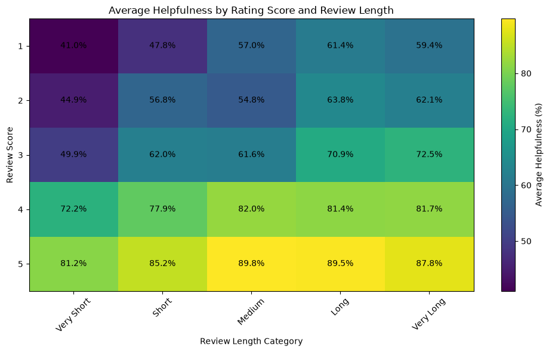

```python
# Create review length categories if not already created
clean_df['ReviewLengthGroup'] = pd.cut(
    clean_df['ReviewLength'],
    bins=[0, 25, 50, 100, 200, float('inf')],
    labels=[
        'Very Short',
        'Short',
        'Medium',
        'Long',
        'Very Long'
    ]
)

# Use only reviews that received helpfulness votes
helpful_reviews = clean_df[
    clean_df['HelpfulnessDenominator'] > 0
].copy()

# Create pivot table of average helpfulness
helpfulness_matrix = pd.pivot_table(
    helpful_reviews,
    values='HelpfulnessRatio',
    index='Score',
    columns='ReviewLengthGroup',
    aggfunc='mean',
    observed=False
) * 100

display(helpfulness_matrix)

# Visualisation - Heatmap
import matplotlib.pyplot as plt

plt.figure(figsize=(10, 6))

plt.imshow(
    helpfulness_matrix,
    aspect='auto'
)

plt.colorbar(label='Average Helpfulness (%)')

plt.xticks(
    range(len(helpfulness_matrix.columns)),
    helpfulness_matrix.columns,
    rotation=45
)

plt.yticks(
    range(len(helpfulness_matrix.index)),
    helpfulness_matrix.index
)

plt.xlabel('Review Length Category')
plt.ylabel('Review Score')
plt.title('Average Helpfulness by Rating Score and Review Length')

# Add values inside the heatmap
for i in range(len(helpfulness_matrix.index)):
    for j in range(len(helpfulness_matrix.columns)):
        value = helpfulness_matrix.iloc[i, j]

        if pd.notna(value):
            plt.text(
                j,
                i,
                f'{value:.1f}%',
                ha='center',
                va='center'
            )

plt.tight_layout()
plt.show()
```

**Observation** : In the analysis, we will compare the average helpfulness ratings and determine which combinations of review length and score are meaningful in identifying cases where specific reviews, such as “long negative reviews,” “medium-length positive reviews,” or “long 5-star reviews,” are perceived as useful by other people.

### 10. Final Discussion

**Key Insights**

- Rating distribution gives a good insight into customer satisfaction.
- It helps in understanding if the reviews are more positive, negative, or moderate.
- At product level, rating score and number of reviews should be taken into account when searching for successful products.
- Analysis at reviewer level allows for identifying those customers who write a lot of reviews and whose reviews generate high usefulness.

**Limitations**

- This dataset provides limited data about the characteristics of products, including `product category`, `product brand`, `product price`, and information related to sellers.
- Names of products are not accessible; therefore, product-level analysis generally utilizes `ProductId` to analyze products.
- Helpfulness analysis can rely on customer voting and many reviews can have fewer votes than suitable.
- Finally, customer behavior and the quality of products may change over time, which means that historical reviews might not completely reflect existing practices.

**Recommendations**

Following this examination, the business must:

1. Evaluating products with good ratings and reviews is one of the best ways to get information about the particular product of your interest.
2. At the same time, it would be wise to think about the products that received bad reviews as this will help point out their weaknesses and flaws.

### 11. Conclusion

The current undertaking assesses the Amazon Fine Food Reviews dataset through the application of exploratory data analysis techniques, featuring a detailed examination of customer ratings, the helpfulness of reviews, reviewer behaviour, product performance, as well as trends in review behaviour over time.

In conclusion, it can be stated that customer reviews have the potential to provide valuable information regarding the product quality and customer experience. Factors such as rating score, review length, helpfulness, review amount and rating variability can be applied to the in-depth insight into consumer judgement mechanisms.

### 12. References

- Stanford Network Analysis Project(SNAP) -> Amazon Fine Food Reviews Dataset.
- Pandas Development Team. -> Pandas Documentation.
- NumPy Developers. -> NumPy Documentation.
- Matplotlib Development Team. -> Matplotlib Documentation.

### Export the Notebook to HTML

```python
# Example:
# !jupyter nbconvert --to html Project.ipynb
```